# Glossary of scRNA-seq terms

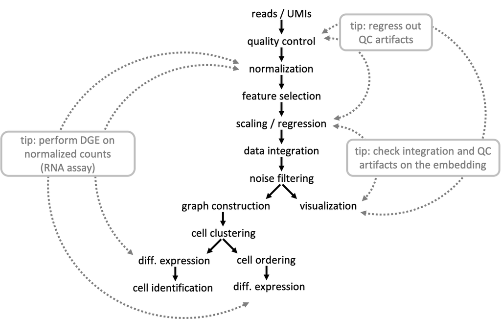

# Downloading data

**Running bash code in RStudio**

It is possible to download data from within RStudio by using the bash code chunk. It is usually a standard to have a folder with all your raw data stored in a separate place from your code or analysis results.

RMarkdown also allows the use of languages other than R, such as bash or Python. To use bash, start the code chunk with `{bash}` instead of `{r}`:

````bash
```{bash}
# Make a data directory
mkdir data

# Use curl to download the data
curl -o data/FILENAME.h5 -O http://FILE_PATH.h5
```
````

# Seurat Objects

[Seurat](https://satijalab.org/seurat/) is one of the most commonly used pipelines for scRNA-seq analysis. For additional information on Seurat objects and commands, please look at this [page](https://satijalab.org/seurat/essential_commands.html). Many different tutorials are also available from their website.

**Reading files**

There are many formats available in which one can store single cell information, many of which cannot all be listed here. The most common formats are:

1. Using tab-delimited matrices saved as `.csv`, `.tsv` or `.txt` and with and additional matrix containing the sample metadata, which is common for SMARTseq2 and related methods
2. Using a compressed **sparse matrix** file `.mtx` with annotations for genes and cells saved as `.tsv`, which was one of the defaults for 10X Chromium data
3. Using HDF5 compressed file for in-file read-write access, which is now becoming the default method for storing single cell dataset (is the current default for 10X Chromium data). HDF5 in particular is fast, scalable and can load parts of the data that will be used at a time, and also can store the metadata in the same file, making it portable. It stores the data as binary compressed **sparse matrix** format

```r
# Read .csv, .tsv, or .txt formats
raw_matrix <- read.delim(
  file      = "data/folder_sample1.csv",
  row.names = 1 )

# Convert to sparse matrix
sparse_matrix <- Matrix::Matrix(
  data   = raw_matrix,
  sparse = T)
rm(raw_matrix)

# Read and convert from the .mtx format (it reads the files in the folder)
sparse_matrix <- Seurat::Read10X(
  data.dir = "data/folder_sample1")

# Read and convert from the .h5 format
sparse_matrix <- Seurat::Read10X_h5(
  filename  = "data/matrix_file.h5",
  use.names = T)
```

Additionally, one should also import any associated metadata file as a `data.frame`, which opposed to a `matrix` can store both numbers, characters, booleans and factors.

```r
# From .csv or .tsv formats
metadata <- read.delim(
  file      = "data/metadata.csv",
  sep       = ",",
  row.names = 1 )
```

**Creating Seurat objects**

In order to make the data analysis process a bit simpler, several single cell developers have implemented their own way of storing the data in a concise format in R and python (called **objects**).

We can now load the expression matrices into objects and then later merge them into a single merged object. Each analysis workflow (Seurat, Scater, Scranpy, etc) has its own way of storing data and here is how you can create a Seurat Object:

```r
SeuratObject <- CreateSeuratObject(
  counts    = sparse_matrix,
  assay     = "RNA",
  project   = "SAMPLE1",
  meta.data = metadata)
```

The `CreateSeuratObject` function can take as input a sparse matrix or a regular matrix with counts.

**Understanding Seurat objects**

Seurat objects have a easy way to access their contents using the `@` or the `$` characters after the object name: * The `@` attribute allows you to access to all analysis slots including: `assays`, `meta.data`, `graphs` and `reduction` slots. * The `$` sign allows you to access the columns of the metadata (just like you normally would do in a data.frame) in your Seurat object directly so that `SeuratObject$column1` is equal to `SeuratObject@meta.data$column1`.

By default, the data is loaded into an `assay` slot named `RNA`, but you can change the names of the slots when creating them (*e.g.*, when creating the seurat object, or computing the reductions). Therefore, check the options in each of the Seurat functions to know where you are storing the data. Each `assay` contains information about the raw counts (`counts`), the normalized counts (`data`), the scaled/regressed data (`scale.data`) as well as information about the dispersion of genes (`var`). Additional assays will be created when doing data analysis, for example when performing data integration, you might store the data as new `assay` or as a new `reduction` slot (depending on the integration method used).

```r
SeuratObject@   # Type this and press TAB in RStudio

SeuratObject@assays$   # Type this and press TAB in RStudio

SeuratObject@assays$RNA@   # Type this and press TAB in RStudio
```

One can check the dimensions and subset Seurat Objects as a dataframe using `dim(SeuratObject)`.

For a very detailed explanation of all slots in the Seurat objects, please refer to the Seurat wiki.

**Add in a metadata column**

You can simply add a column by using the `$` sign to allocate a vector to a metadata column.

```r
SeuratObject$NEW_COLUMN_NAME <- setNames(
  colnames(SeuratObject),
  vector_NEW_DATA)
```

Or use the function `AddMetaData` to add one or multiple columns:

```r
SeuratObject <- AddMetaData(
  object   = SeuratObject,
  metadata = vector_NEW_DATA,
  col.name = "NEW_COLUMN_NAME")
```

**Subsetting Seurat objects**

To subset a Seurat object, you can do it as if was a dataframe:

```r
# Subsetting Features
SeuratObject <- SeuratObject[vector_FEATURES_TO_USE, ]

# Subsetting Cells
SeuratObject <- SeuratObject[, vector_CELLS_TO_USE ]
```

**Plotting functions**

The most common functions to use for plotting are the violin plot and the scatter plots for the dimensionality reduction calculated (you need to calculate it before using the function!).

To plot **continuous** variables as **violin** (press TAB inside the functions for more options):

```r
VlnPlot(object   = SeuratObject,
        group.by = "orig.ident",
        features = c("percent_mito"),
        pt.size  = 0.1,
        ncol     = 4,
        y.max    = 100) +
  NoLegend()
```

To plot **continuous** variables as **scatter plot** using the `umap` reduction slot (press TAB inside the functions for more options):

```r
FeaturePlot(object    = SeuratObject,
            features  = c("FEATURE_1","FEATURE_2","FEATURE_3"),
            reduction = "umap",
            dims      = c(1,2),
            order     = TRUE,
            pt.size   = .1,
            ncol      = 3)
```

To plot **CATEGORICAL** variables as **scatter plot** using the `umap` reduction slot (press TAB inside the functions for more options):

```r
DimPlot(object    = SeuratObject,
        group.by  = c("DATASET"),
        reduction = "umap",
        dims      = c(1, 2),
        pt.size   = .1,
        label     = TRUE,
        ncol      = 3)
```

Many other plotting functions are available, check `Seurat::` (then press tab and look for the functions with “Plot” in the name).

**Combine datasets**

```r
CombinedSeuratObject <- merge(
  x            = SeuratObject1,
  y            = c(SeuratObject2, SeuratObject3, SeuratObject4),
  add.cell.ids = c("Dataset1", "Dataset2", "Dataset3", "Dataset4"))
```